# Assignment1

Junhao Ou & 21200066

2022-09-26

# Task 1: Manipulation

## 1. Load the dataset EurostatCrime2019.csv

In this section, we will load the dataset

```r
df = read.csv('EurostatCrime2019.csv',row.names = 1)
```

## 2. Structure Check

In this section, we will check the size (number of rows and columns) and the structure of this data.

```r
str(df)
```

```
## 'data.frame':    41 obs. of  13 variables:
##  $ Intentional.homicide                                  : num  2.03 0.84 1.27 NA 1.14 0.81 1.48 0.76 0.91 NA ...
##  $ Attempted.intentional.homicide                        : num  3.25 1.93 8.87 NA 0.54 2.4 1.71 0.58 2.57 NA ...
##  $ Assault                                               : num  5.52 43.29 556.36 NA 39.54 ...
##  $ Kidnapping                                            : num  0.14 0.07 NA NA 1.03 0.02 0.91 0.11 NA NA ...
##  $ Sexual.violence                                       : num  5.38 50.9 77.45 NA 8.64 ...
##  $ Rape                                                  : num  2.69 18.92 33.33 NA 1.87 ...
##  $ Sexual.assault                                        : num  2.69 26.64 44.12 NA NA ...
##  $ Robbery                                               : num  3.42 29.67 140.14 NA 16.9 ...
##  $ Burglary                                              : num  NA 613.2 565.9 NA 79.8 ...
##  $ Burglary.of.private.residential.premises              : num  40.4 99.3 410.1 NA NA ...
##  $ Theft                                                 : num  169 1303 1952 NA 474 ...
##  $ Theft.of.a.motorized.land.vehicle                     : num  11.1 44.2 109.8 NA 18.9 ...
##  $ Unlawful.acts.involving.controlled.drugs.or.precursors: num  70.3 494.1 547.7 NA 78.1 ...
```

As we can see, the size of the table is 41 rows by 13 columns.

## 3. Produce appropriate commands to do the following actions.

### (i) Remove the columns of Rape and Sexual.assault.

```r
df = df[,-which(names(df) %in% c('Rape','Sexual.assault'))]
str(df)
```

```
## 'data.frame':    41 obs. of  11 variables:
##  $ Intentional.homicide                                  : num  2.03 0.84 1.27 NA 1.14 0.81 1.48 0.76 0.91 NA ...
##  $ Attempted.intentional.homicide                        : num  3.25 1.93 8.87 NA 0.54 2.4 1.71 0.58 2.57 NA ...
##  $ Assault                                               : num  5.52 43.29 556.36 NA 39.54 ...
##  $ Kidnapping                                            : num  0.14 0.07 NA NA 1.03 0.02 0.91 0.11 NA NA ...
##  $ Sexual.violence                                       : num  5.38 50.9 77.45 NA 8.64 ...
##  $ Robbery                                               : num  3.42 29.67 140.14 NA 16.9 ...
##  $ Burglary                                              : num  NA 613.2 565.9 NA 79.8 ...
##  $ Burglary.of.private.residential.premises              : num  40.4 99.3 410.1 NA NA ...
##  $ Theft                                                 : num  169 1303 1952 NA 474 ...
##  $ Theft.of.a.motorized.land.vehicle                     : num  11.1 44.2 109.8 NA 18.9 ...
##  $ Unlawful.acts.involving.controlled.drugs.or.precursors: num  70.3 494.1 547.7 NA 78.1 ...
```

### (ii) Remove the columns involving theft and burglary

```r
library(dplyr)
df = select(df, -contains("Theft"))
df = select(df, -contains("Burglary"))
str(df)
```

```
## 'data.frame':    41 obs. of  7 variables:
##  $ Intentional.homicide                                  : num  2.03 0.84 1.27 NA 1.14 0.81 1.48 0.76 0.91 NA ...
##  $ Attempted.intentional.homicide                        : num  3.25 1.93 8.87 NA 0.54 2.4 1.71 0.58 2.57 NA ...
##  $ Assault                                               : num  5.52 43.29 556.36 NA 39.54 ...
##  $ Kidnapping                                            : num  0.14 0.07 NA NA 1.03 0.02 0.91 0.11 NA NA ...
##  $ Sexual.violence                                       : num  5.38 50.9 77.45 NA 8.64 ...
##  $ Robbery                                               : num  3.42 29.67 140.14 NA 16.9 ...
##  $ Unlawful.acts.involving.controlled.drugs.or.precursors: num  70.3 494.1 547.7 NA 78.1 ...
```

### (iii) Add a column containing the overall record of offences for each country (per hundred thousand inhabitants)

```r
df['Overall Record'] = rowSums(df[,c(1:7)])
```

## 4. List the countries that contain any missing data.

```r
row.names(df[rowSums(is.na(df)) > 0,])
```

```
##  [1] "Belgium"                "Bosnia and Herzegovina" "Denmark"
##  [4] "England and Wales"      "Estonia"                "France"
##  [7] "Hungary"                "Iceland"                "Liechtenstein"
## [10] "Netherlands"            "North Macedonia"        "Northern Ireland (UK)"
## [13] "Norway"                 "Poland"                 "Portugal"
## [16] "Scotland"               "Slovakia"               "Sweden"
## [19] "Turkey"
```

## 5. Remove the countries with missing data from the dataframe.

```r
df = subset(df,rowSums(is.na(df)) <= 0)
df
```

|  | Intentional.homicide | Attempted.intentional.homicide | Assault | Kidnapping | Sexual.violence | Robbery | Unlawful.acts.involving.controlled.drugs.or.precursors | Overall Record |
| --- | --- | --- | --- | --- | --- | --- | --- | --- |
| Albania | 2.03 | 3.25 | 5.52 | 0.14 | 5.38 | 3.42 | 70.26 | 90.00 |
| Austria | 0.84 | 1.93 | 43.29 | 0.07 | 50.90 | 29.67 | 494.05 | 620.75 |
| Bulgaria | 1.14 | 0.54 | 39.54 | 1.03 | 8.64 | 16.90 | 78.14 | 145.93 |
| Croatia | 0.81 | 2.40 | 18.06 | 0.02 | 21.05 | 20.56 | 272.16 | 335.06 |
| Cyprus | 1.48 | 1.71 | 20.09 | 0.91 | 1.94 | 6.28 | 117.82 | 150.23 |
| Czechia | 0.76 | 0.58 | 43.98 | 0.11 | 14.65 | 13.51 | 45.25 | 118.84 |
| Finland | 1.59 | 5.96 | 28.71 | 0.02 | 72.65 | 32.71 | 586.14 | 727.78 |
| Germany (until 1990 former territory of the FRG) | 0.71 | 2.18 | 160.31 | 5.44 | 49.05 | 43.43 | 433.33 | 694.45 |
| Greece | 0.71 | 1.09 | 14.95 | 0.66 | 2.83 | 40.00 | 126.76 | 187.00 |
| Ireland | 0.71 | 0.55 | 102.18 | 1.71 | 67.86 | 41.66 | 421.84 | 636.51 |

[output cut: 12 more lines]

## 6. How many observations and variables are in this new dataframe?

```r
str(df)
```

```
## 'data.frame':    22 obs. of  8 variables:
##  $ Intentional.homicide                                  : num  2.03 0.84 1.14 0.81 1.48 0.76 1.59 0.71 0.71 0.71 ...
##  $ Attempted.intentional.homicide                        : num  3.25 1.93 0.54 2.4 1.71 0.58 5.96 2.18 1.09 0.55 ...
##  $ Assault                                               : num  5.52 43.29 39.54 18.06 20.09 ...
##  $ Kidnapping                                            : num  0.14 0.07 1.03 0.02 0.91 0.11 0.02 5.44 0.66 1.71 ...
##  $ Sexual.violence                                       : num  5.38 50.9 8.64 21.05 1.94 ...
##  $ Robbery                                               : num  3.42 29.67 16.9 20.56 6.28 ...
##  $ Unlawful.acts.involving.controlled.drugs.or.precursors: num  70.3 494.1 78.1 272.2 117.8 ...
##  $ Overall Record                                        : num  90 621 146 335 150 ...
```

# Task 2: Analysis

## 1. According to these data what were the 3 most common crimes in Ireland in 2019?

Then, we will implement a function that can return the 3 most common crimes with input country.

```r
maxthree = function(data, row) {
    x <- data[row,1:7]
    return(x[order(x, decreasing = T)][1:3])
}
```

Check the 3 most common crimes in Ireland in 2019

```r
maxthree(df, "Ireland")
```

|  | Unlawful.acts.involving.controlled.drugs.or.precursors | Assault | Sexual.violence |
| --- | --- | --- | --- |
| Ireland | 421.84 | 102.18 | 67.86 |

## 2. What proportion of the overall crimes was due to Assault in Ireland in 2019?

We will implement a function that can return the proportion of any type of crime of any country.

```r
propCal = function(data,country,crime) {
  prop = data[country,crime]/data[country,'Overall Record']
  return(prop)
}
```

Check the proportion of the overall crimes was due to Assault in Ireland.

```r
propCal(df, "Ireland",'Assault')
```

```
## [1] 0.1605316
```

## 3. Which country had the highest record of kidnapping in 2019.

```r
rownames(df)[order(df[,'Kidnapping'], decreasing = T)][1]
```

```
## [1] "Luxembourg"
```

## 4. Which country had the lowest overall record of offences in 2019 (per hundred thousand inhabitants)?

```r
rownames(df)[order(df[,'Overall Record'], decreasing = F)][1]
```

```
## [1] "Romania"
```

## 5. Create a plot displaying the relationship between robbery and unlawful acts involving controlled drugs or precursors. Make the plot look “nice” i.e. change axis labels etc.

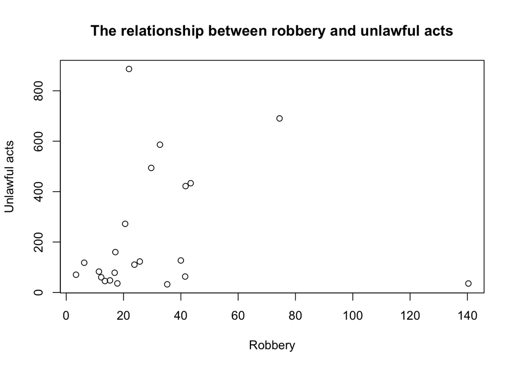

```r
plot(df$Robbery,df$Unlawful.acts.involving.controlled.drugs.or.precursors,xlab='Robbery',ylab='Unlawful acts',main='The relationship between robbery and unlawful acts')
```

# Task 3: Creativity

1. We will plot the histogram of Overall Record for each country

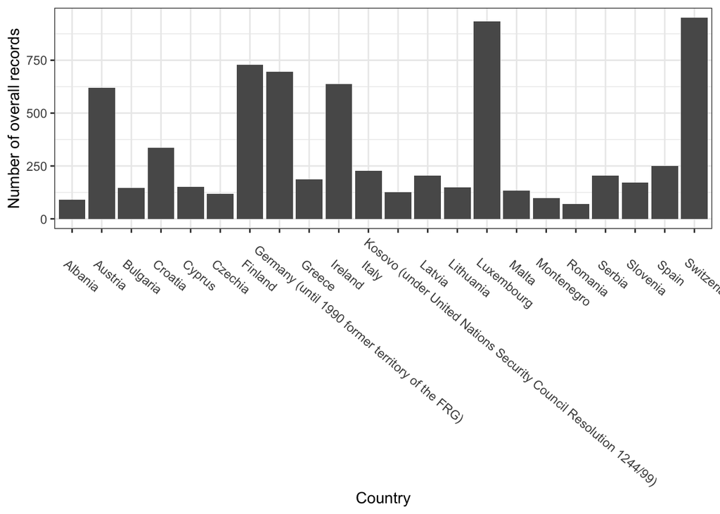

```r
library(reshape2)
library(ggplot2)
df1 <- melt(df$'Overall Record',id.vars="Row.names")
ggplot(df1, aes(x = rownames(df), y=value))+geom_bar(stat="identity", position ="dodge")+theme_bw()+theme(axis.text.x = element_text(angle=-40, hjust=.1))+labs(x = "Country",y='Number of overall records')
```

From the plot above, we can conclude that the top 5 countries with the greatest number of crime records are Luxembourg, Swizerland, Finland, Germany and Ireland.